# Book club: The Art of Statistics Chapters 9 & 10

Michael Naylor

12 November 2020

# Chapter 9: Putting Probability and Statistics Together

# Start with a population

- If there were 20% left handers in the population what would I see?
- Resample - like bootstrapping, but theoretically
- Bigger n less variation in the answer

# Changing n

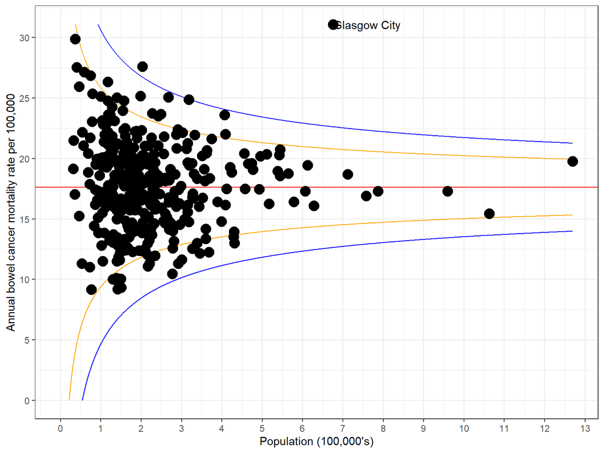

[output not shown]